# Reaction times for Estonian case-inflected nouns: solution

Matteo Fasiolo

2023-10-06

1. Load data and fit a basic Gaussian GAM:

```r
library(testGam)
library(mgcViz)
data("est")

m1 <- qgamV(RT ~ InfFamSize + Age + LogFrequency + WordLength + Trial,
            data=est, qu=0.5)
```

```
## Estimating learning rate. Each dot corresponds to a loss evaluation.
## qu = 0.5........done
```

```r
summary(m1)
```

```
##
## Family: elf
## Link function: identity
##
## Formula:
## RT ~ InfFamSize + Age + LogFrequency + WordLength + Trial
##
## Parametric coefficients:
##               Estimate Std. Error z value Pr(>|z|)
## (Intercept)  529.05153   25.44502  20.792  < 2e-16 ***
## InfFamSize   -15.60189    4.39435  -3.550 0.000385 ***
## Age            3.83973    0.22557  17.022  < 2e-16 ***
## LogFrequency -17.00980    1.55563 -10.934  < 2e-16 ***
## WordLength    29.91975    1.65186  18.113  < 2e-16 ***
## Trial          0.00211    0.05151   0.041 0.967325
## ---
## Signif. codes:  0 '***' 0.001 '**' 0.01 '*' 0.05 '.' 0.1 ' ' 1
##
##
## R-sq.(adj) =  0.211   Deviance explained = 18.1%
## -REML =  36205  Scale est. = 1         n = 5131
```

`Trial` does not seem to have a strong (linear) effect.

2. Look at fraction of observations falling below the fit:

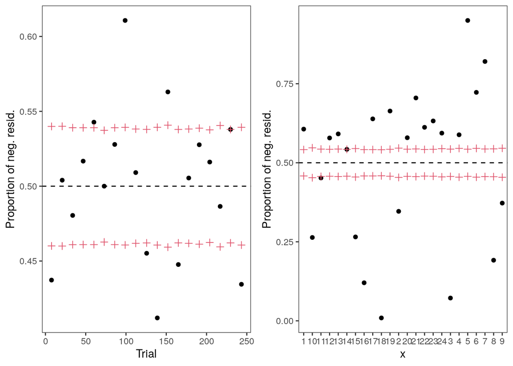

```r
pl <- check1D(m1, x = list("Trial", est$Subject)) + l_gridQCheck1D(qu = 0.5)
print(pl, pages = 1)
```

There is a clear non-linear pattern along `Trial`, and there are massive individual differences (depending on `subject`).

3. Add smooth for `Trial` and a random effect for `Subject`:

```r
m1 = qgamV(RT ~ InfFamSize + Age + LogFrequency + WordLength + s(Trial) + s(Subject, bs="re"),
           data=est, qu=0.5)
```

```
## Estimating learning rate. Each dot corresponds to a loss evaluation.
## qu = 0.5..................done
```

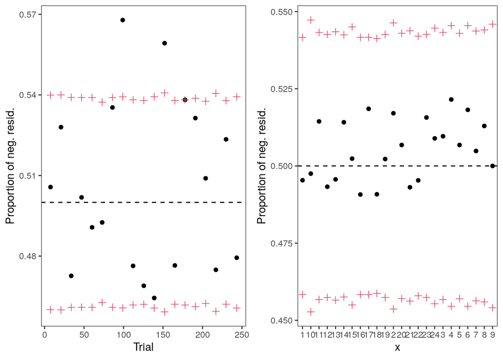

```r
pl <- check1D(m1, x = list("Trial", est$Subject)) + l_gridQCheck1D(qu = 0.5)
print(pl, pages = 1)
```

```r
summary(m1)
```

```
##
## Family: elf
## Link function: identity
##
## Formula:
## RT ~ InfFamSize + Age + LogFrequency + WordLength + s(Trial) +
##     s(Subject, bs = "re")
##
## Parametric coefficients:
##              Estimate Std. Error z value Pr(>|z|)
## (Intercept)   520.501     78.709   6.613 3.77e-11 ***
## InfFamSize    -13.655      3.448  -3.961 7.48e-05 ***
## Age             3.990      1.651   2.417   0.0157 *
## LogFrequency  -16.143      1.215 -13.288  < 2e-16 ***
## WordLength     30.544      1.257  24.296  < 2e-16 ***
## ---
## Signif. codes:  0 '***' 0.001 '**' 0.01 '*' 0.05 '.' 0.1 ' ' 1
##
## Approximate significance of smooth terms:
##               edf Ref.df  Chi.sq p-value
## s(Trial)    5.045  6.155   22.16 0.00127 **
## s(Subject) 21.750 23.000 1751.47 < 2e-16 ***
## ---
## Signif. codes:  0 '***' 0.001 '**' 0.01 '*' 0.05 '.' 0.1 ' ' 1
##
## R-sq.(adj) =  0.393   Deviance explained = 33.5%
## -REML =  35273  Scale est. = 1         n = 5131
```

There are still some departures from 0.5 along `Trial`, but there is some improvement and the non-linear effect of `Trial` seems important. The diagnostic plot along `Subject` now look very good. Notice that both effects are significant.

4. Try tensor effect

```r
m1 <- qgamV(RT ~ InfFamSize + Age + te(LogFrequency, WordLength) + s(Trial) + s(Subject, bs="re"),
            data=est, qu=0.5)
```

```
## Estimating learning rate. Each dot corresponds to a loss evaluation.
## qu = 0.5...........done
```

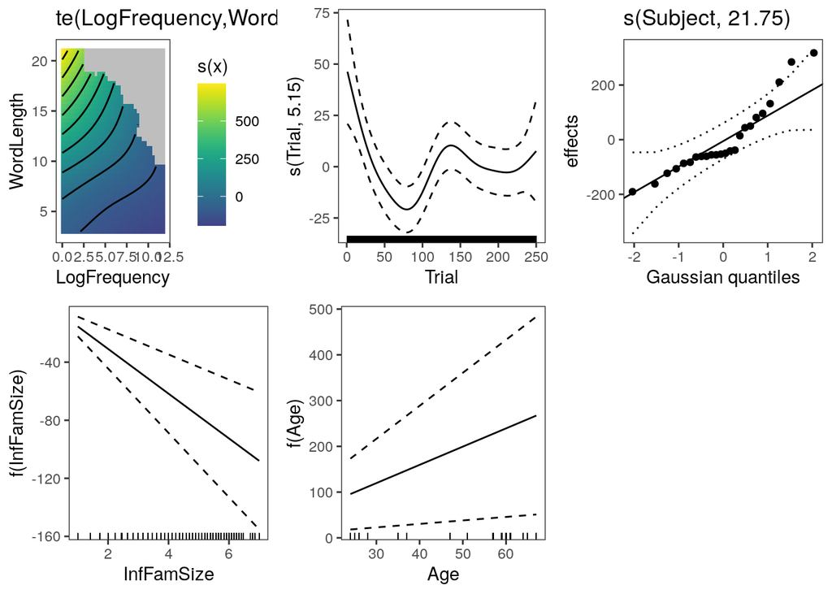

```r
print(plot(m1, allTerms = TRUE), pages = 1)
```

```r
plotRGL(sm(m1, 1), residuals = T)
rglwidget()
```

[interactive chart not shown]

The bivariate effect of `LogFrequency` and `WordLength` looks pretty linear to me! We are probably better off using two linear effects.

5. Fit several quantile models

```r
qus <- seq(0.1, 0.9, length.out = 5)
m1 = mqgamV(RT ~ InfFamSize + Age + LogFrequency + WordLength + s(Subject, bs="re") + s(Trial),
            data=est, qu=qus)
```

```
## Estimating learning rate. Each dot corresponds to a loss evaluation.
## qu = 0.5..........done
## qu = 0.3................done
## qu = 0.7.............done
## qu = 0.1...........done
## qu = 0.9.........done
```

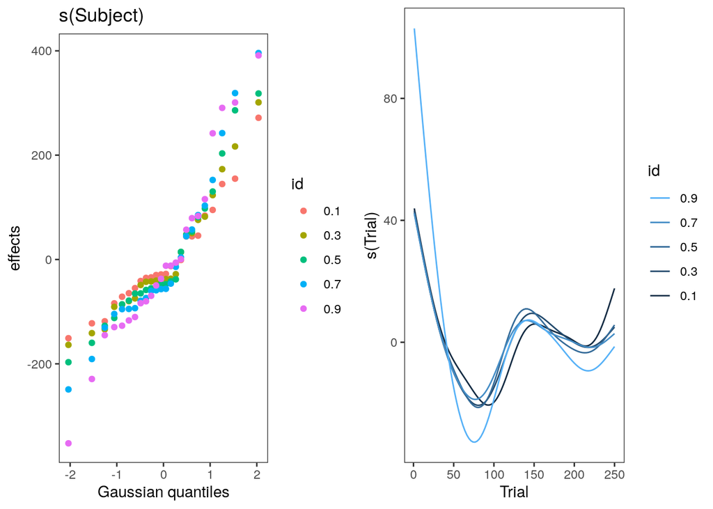

```r
# Plotting all smooth effects
print(plot(m1), pages = 1)
```

We now plot also the parametric effects:

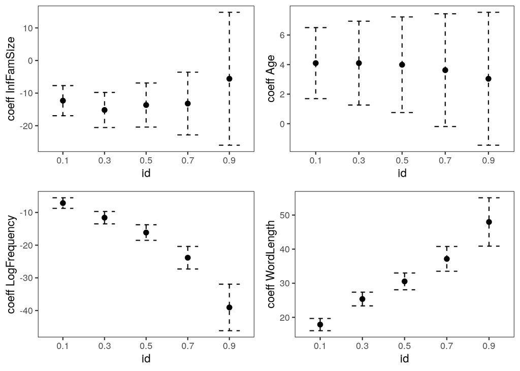

```r
print(plot(m1, allTerms = TRUE, select = 3:6), pages = 1)
```

Notice that all the confidence intervals get wider as we move toward the highest quantile (0.9). This is normal, as the response times distribution is very skewed to the right, hence the data is quite sparse around high quantile. The effects of word frequency and length get stronger as we look at slower responses.